# 分形

22920242203150 2025-12-14

课程代码均在如下 GitHub 仓库开源：https://github.com/GHe0000/scientific-programming-intro

## 目录

- 作业要求
- Lorenz 吸引子维数
  - 吸引子采样
  - 计盒维数
  - 信息维数
  - 关联维数
- The Mandelbrot Set
  - 绘制
  - 不同区域发散速度
  - 不同区域收敛轨道周期
- 周期一，二，五轨道
  - 周期一
  - 周期二
  - 周期五
  - 临界慢化
- 分叉图
  - 沿实轴分叉图
  - 二维平面分叉图
- 结论
  - Lorenz 吸引子维数
  - The Mandelbrot Set
- 参考资料
- 致谢
- 附一：问题
- 附二：学习心得

## 作业要求

- 计算 Lorentz 吸引子的信息维数和关联维数，跟其李指数维数进行比较.
- 画出一个 The Mandelbrot Set
- 展示周期一，周期二和周期五轨道
- 画出沿实数轴 C 的分叉图

## Lorenz 吸引子维数

### 吸引子采样

导入需要的库，并针对 Jupyter Notebook 进行一些设置.

```python
import numpy as np # 数值计算库
import numba as nb # 引入 jit 来加速函数（如果需要）
import sympy as sym # 符号计算库
import matplotlib as mpl
import matplotlib.pyplot as plt # 图像绘制
from matplotlib.backends.backend_agg import FigureCanvasAgg # 设置图像后端用
import ipywidgets as ipw # 交互控件
from IPython.display import display, Math, Latex # 打印数学公式
import time
import tracemalloc

import matplotlib.animation as animation # 创建动画
from IPython.display import HTML # 动画嵌入
import scipy

from sklearn.linear_model import RANSACRegressor
from scipy.spatial import cKDTree

# 使用 mathjax 来在 jupyter notebook 显示数学公式
sym.init_printing(use_latex='mathjax')

# 设置 matplotlib 绘制的图像嵌入到 jupyter notebook 的方式
%matplotlib widget

# 一个工具函数，可以让静态图片不经过 widget 直接嵌入 Jupyter notebook
# 这样图片可以直接存到 nb 文件里，而不是需要运行才能显示（类似 inline）
def display_inline(fig):
    fig.set_canvas(FigureCanvasAgg(fig))
    display(fig)
    plt.close(fig) # 释放 fig，减小资源消耗

# 一个工具函数，用于在 Jupyter 中快速实现公式和字符串混合输出
def display_math(*args):
    parts = []
    for a in args:
        if isinstance(a, str):
            parts.append(a)
        else:
            parts.append(sym.latex(a))
    display(Math("".join(parts)))

# 设置 matplotlib 使用的字体，避免出现中文问题
plt.rcParams['font.family'] = ['SimSun', 'Times New Roman']
plt.rcParams['mathtext.fontset'] = 'cm'
# 设置默认坐标轴字体大小
plt.rcParams['axes.labelsize'] = 14

# 设置种子，保证可重复性
np.random.seed(3407)
```

对于 Lorenz 系统，迭代方程为：

$$ \begin{aligned} \dot x &= \sigma (y-x) \\ \dot y &= x(\rho-z) - y \\ \dot z &= xy - \beta z \end{aligned} $$

迭代使用四阶龙格库塔法（RK4）. 算法实现类似第五次作业，这里不再赘述.

同时，在下面的计算中，根据作业要求，统一取 $\sigma=10, \rho=28, \beta=8/3$

```python
@nb.njit(cache=True)
def lorenz_sample(skip_n, save_n, per_n, dt=0.01):
    def lorenz(state, sigma=10.0, rho=28.0, beta=8.0/3.0):
        x, y, z = state
        dx = sigma * (y - x)
        dy = x * (rho - z) - y
        dz = x * y - beta * z
        return np.array([dx, dy, dz])
    def rk4_step(state, dt):
        k1 = lorenz(state)
        k2 = lorenz(state + k1 * dt * 0.5)
        k3 = lorenz(state + k2 * dt * 0.5)
        k4 = lorenz(state + k3 * dt)
        return state + (k1 + 2*k2 + 2*k3 + k4) * (dt / 6.0)
    X = np.array([0.1, 0.0, 0.0])
    for _ in range(skip_n):
        X = rk4_step(X, dt)
    ret = np.empty((save_n, 3), dtype=np.float64)
    for i in range(save_n):
        ret[i] = X
        for _ in range(per_n):
            X = rk4_step(X, dt)
    return ret
```

我们跳过前 $50000$ 步以去除暂态过程，并进行采样，采样前 $10^5$ 个点，如下：

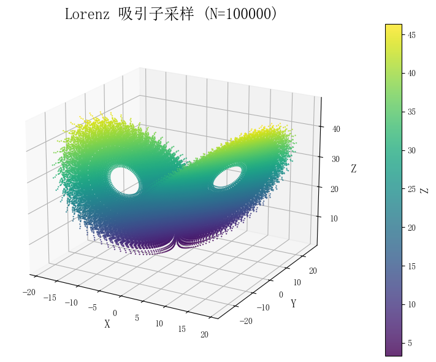

```python
skip_n = 50000
save_n = int(1e5)
per_n = 1
dt = 0.01

traj = lorenz_sample(skip_n, save_n, per_n, dt)

fig = plt.figure(figsize=(8, 6))
ax = fig.add_subplot(111, projection='3d')
sc = ax.scatter(traj[:, 0], traj[:, 1], traj[:, 2],
                s=0.5, c=traj[:, 2], cmap='viridis', alpha=0.8)
ax.set_title(f"Lorenz 吸引子采样 (N={save_n})", size=18)
ax.set_xlabel("X")
ax.set_ylabel("Y")
ax.set_zlabel("Z")
plt.colorbar(sc, label='Z', pad=0.1)
ax.view_init(elev=20, azim=-60)

plt.tight_layout()
display_inline(fig)
```

可以看到，我们采样的点确实已经去掉了暂态过程. 并且在吸引子各处基本均有分布.

受限于绘图速度（Matplotlib 3D 绘图在点的数量巨大的情况下非常慢）. 这里只绘制了 $10^5$ 个点. 但在实际计算中我们会采集更多的点，从而提升计算精度. 考虑到任何维度的计算都是分析不同尺度下的点之间的关系. 因此在不同尺度下均需要有足够数量的点.

### 计盒维数

#### 使用 Numpy 内置函数

首先，根据课堂上的介绍，我们使用 `np.histogramdd` 进行计算，函数实现如下：

```python
def calc_box_counts_use_histogramdd(traj, n_arr):
    num_n = len(n_arr)
    res = np.empty(num_n, dtype=np.int64)

    min_vals = np.min(traj, axis=0)
    max_vals = np.max(traj, axis=0)
    margin = (max_vals - min_vals) * 1e-5
    min_vals -= margin
    max_vals += margin
    bins_range = np.stack((min_vals, max_vals), axis=1)

    for i, n in enumerate(n_arr):
        n = int(n)
        H, _ = np.histogramdd(traj, bins=n, range=bins_range)
        res[i] = np.count_nonzero(H)
    return res
```

上述函数很简洁，但在后面的计算中发现有如下问题：计算过程中内存占用过高. `np.histogramdd` 会在内部生成一个 $n \times n \times n$ 的网格（3 维下）并统计每个点在哪一个网格. 这实际上是比较低效的，因为大部分网格都是没有数据的. 会白白占用内存，导致内存占用巨大（在划分比较多的情况下）.

同时 `np.histogramdd` 并不方便使用 `numba` 进行加速和并行化. 不能批量计算 $n$ 对应的占用格子数.

由于在使用中发现了上述问题，这里我给出一个更高效的实现.

#### 自行实现

这里我将其分成两部分：(1). 计算每个点所属网格 (2). 计算有多少网格以及每个网格点数（方便后面信息维数使用）

(1) 计算每个点所属网格：假设某一个点坐标 $(x,y,z)$. 所有点的坐标的最小值为 $(x_m,y_m,z_m)$，最大值为 $(x_M,y_M,z_M)$. 则每一个点所位于的网格 $(i_x,i_y,i_z)$ 为（假设每边分 $n$ 个网格）：

$$ i_x = \mathrm{int}\left(\frac{x - x_m}{dx}\right),\quad dx = \frac{x_M - x_m}{n} $$

$i_y,i_z$ 同理，$\mathrm{int}$ 为取整函数. 上述过程完全可以向量化，一次性计算出所有点的所在格数.

(2) 统计每个网格点数. 这里我们使用计算机科学中的 Hash Map 中 Hash 函数的思想. 定义如下 Hash 函数：

$$ h(i_x, i_y, i_z) = i_x + n i_y + n^2 i_z $$

这样每一个网格都唯一被一个 $h$ 表示，对每个点，计算出其对应网格的 Hash 值 $h_i$. 对 $h_i$ 排序. 此时统计不同的 $h_i$ 有多少，以及每一个 $h_i$ 个数.（遍历一遍 $h_i$ 数数即可）. 从而得到所有被占用的格子数以及被占用格子中点数目.

假设一共有 $N$ 个点，每边分 $n$ 格. 则使用原生函数的算法的时间复杂度为 $O(N)$. 空间复杂度为 $O(n^3)$. 我自行实现的算法的时间复杂度为 $O(N \log N)$（排序需要 $O(N \log N)$）. 空间复杂度为 $O(N)$. 可见，这里在略微提升了时间复杂度的情况下，极大降低了空间复杂度（总网格数往往大于采样点数）.

另一方面，这里的实现非常适合进行并行化多线程计算. 因此实际的计算效率会比使用原生函数更高.

这里的实现如下：

```python
@nb.njit(parallel=True, cache=True)
def calc_box_counts(traj, n_arr):
    n_pts = len(traj)
    num_n = len(n_arr)
    res = np.empty(num_n, dtype=np.int64)

    min_vals = np.empty(3, dtype=np.float64)
    max_vals = np.empty(3, dtype=np.float64)
    for k in range(3):
        min_vals[k] = np.min(traj[:, k])
        max_vals[k] = np.max(traj[:, k])
    margin = (max_vals - min_vals) * 1e-5
    min_vals -= margin
    max_vals += margin

    # 并行计算
    for i in nb.prange(num_n):
        n = int(n_arr[i])
        dx = (max_vals[0] - min_vals[0]) / n
        dy = (max_vals[1] - min_vals[1]) / n
        dz = (max_vals[2] - min_vals[2]) / n
        hashes = np.empty(n_pts, dtype=np.int64)

        for p_idx in range(n_pts):
            ix = int((traj[p_idx, 0] - min_vals[0]) / dx)
            iy = int((traj[p_idx, 1] - min_vals[1]) / dy)
            iz = int((traj[p_idx, 2] - min_vals[2]) / dz)
            if ix >= n: ix = n - 1 # 分界处特殊处理
            if iy >= n: iy = n - 1
            if iz >= n: iz = n - 1
            hashes[p_idx] = ix + iy * n + iz * n * n
        hashes.sort()

        n_boxes = 0
        if n_pts > 0:
            n_boxes = 1
            for k in range(1, n_pts):
                if hashes[k] != hashes[k-1]:
                    n_boxes += 1
        res[i] = n_boxes
    return res
```

#### 对比

为了验证两种算法确实是相同的，并比较两者的计算速度和内存占用. 我们对相同的采样点集进行计算，如下：

```
自行实现: 耗时 0.633s 内存占用峰值: 61.05 MB
使用 histogramdd: 耗时 3.946s 内存占用峰值: 606.81 MB
```

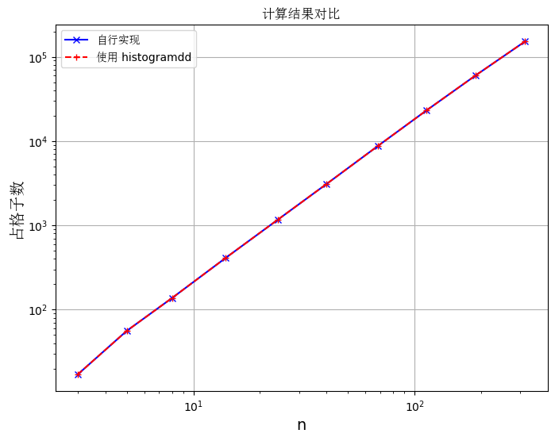

```python
traj = lorenz_sample(skip_n=50000, save_n=int(2e6), per_n=1)
n_arr = np.unique(np.logspace(0.5, 2.5, num=10, dtype=int))

tracemalloc.start()
t0 = time.time()
res1 = calc_box_counts(traj, n_arr)
current, peak = tracemalloc.get_traced_memory()
print(f"自行实现: 耗时 {time.time() - t0:.3f}s 内存占用峰值: {peak / 1024 / 1024:.2f} MB")
tracemalloc.stop()

tracemalloc.start()
t0 = time.time()
res2 = calc_box_counts_use_histogramdd(traj, n_arr)
current, peak = tracemalloc.get_traced_memory()
print(f"使用 histogramdd: 耗时 {time.time() - t0:.3f}s 内存占用峰值: {peak / 1024 / 1024:.2f} MB")
tracemalloc.stop()

plt.rcParams['font.family'] = ['DejaVu Sans','SimSun', 'Times New Roman'] # 临时设置字体，消除上标的负号问题
fig, ax = plt.subplots(figsize=(8,6))
ax.loglog(n_arr, res1, "b-x", label='自行实现')
ax.loglog(n_arr, res2, "r--+", label='使用 histogramdd')
ax.legend()
ax.grid()
ax.set_title("计算结果对比")
ax.set_xlabel("n")
ax.set_ylabel("占格子数")
display_inline(fig)
plt.rcParams['font.family'] = ['SimSun', 'Times New Roman']
```

可见，使用自行实现的算法，在耗时减少，内存占用大幅度降低的情况下，计算结果仍旧保持不变. 因此，在后续的计算中（包括信息维度），均使用自行实现的函数进行计算. 以减少计算的耗时以及内存占用.

#### 正式计算

首先，我们对 Lorenz 吸引子采样 $10^8$ 个点.

```python
save_n = int(1e8)
t0 = time.time()
print("开始采样...")
traj = lorenz_sample(skip_n=50000, save_n=save_n, per_n=1)
print(f"采样结束，耗时 {time.time()-t0:.3f} s")
```

```
开始采样...
采样结束，耗时 107.751 s
```

我们在 $10^{0.5}$ 到 $10^{4.5}$ 中采样 $50$ 个点（在对数空间中均匀采样）. 并计算占用格数：

```python
n_arr = np.unique(np.logspace(0.5, 4.5, num=50, dtype=int))
print("预编译")
box_counts = calc_box_counts(traj[:5], n_arr[:2])
t0 = time.time()
print("开始计算...")
box_counts = calc_box_counts(traj, n_arr)
print(f"计算结束，耗时 {time.time()-t0:.3f} s")
```

```
预编译
开始计算...
计算结束，耗时 290.218 s
```

在 log-log 坐标中绘制每边分格数和占用格数，如下：

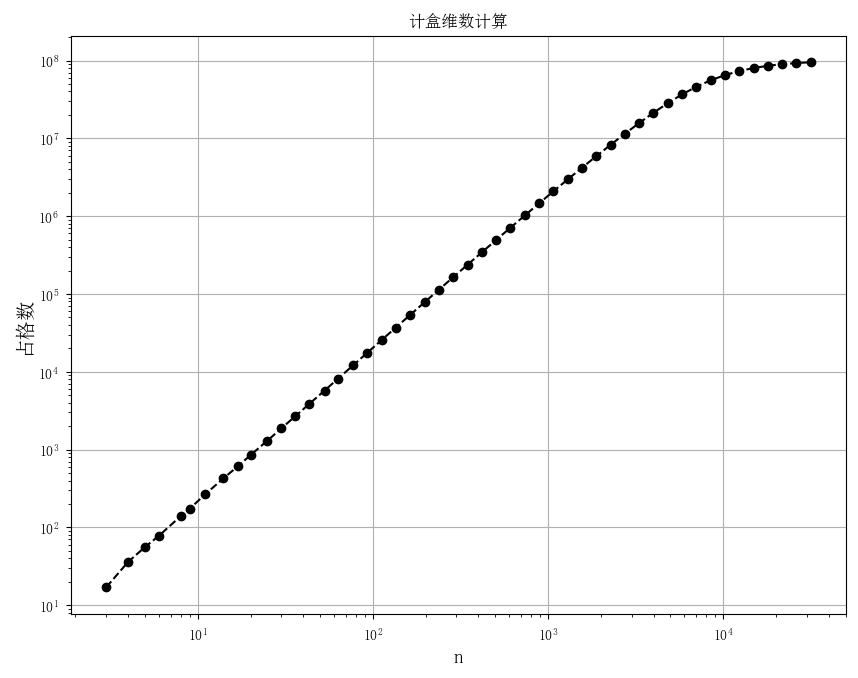

```python
fig, ax = plt.subplots(figsize=(8,6))
ax.loglog(n_arr, box_counts, "k--o")
ax.grid()
ax.set_xlabel("n")
ax.set_ylabel("占格数")
ax.set_title("计盒维数计算")
display_inline(fig)
```

可见，在 $n$ 较大的时候出现“饱和”. 这部份点是需要去除的. 这里我们可以认为去除 $n$ 较大的点. 但比较主观. 这里我参考了 Python 中 `nolds` 库的实现方式（`nolds` 是一个用于分析一维混沌系统的库）. 使用 RANSAC 方法来自动选取拟合度较高的点. 自动排除非线性的点. 具体而言，其随机取点进行拟合，并验证哪一个拟合结果能使得在偏差内的点最多（允许偏差人为设定）. 则取能使得在给定偏差内的点最多的拟合结果. 这里我们直接使用 `scikit-learn` 中的实现.

```python
def fit_and_plot_ransac(ax, x, y, res_threshold=0.01):
    X = x.reshape(-1, 1)
    Y = y
    ransac = RANSACRegressor(min_samples=2,
                             residual_threshold=res_threshold,
                             random_state=42)
    ransac.fit(X, Y)
    inlier_mask = ransac.inlier_mask_
    outlier_mask = np.logical_not(inlier_mask)
    line_x = np.linspace(x.min(), x.max(), 100).reshape(-1, 1)
    line_y = ransac.predict(line_x)
    slope = ransac.estimator_.coef_[0]
    ax.scatter(x[outlier_mask], y[outlier_mask], color='r', marker='x', s=15, label='舍弃点')
    ax.scatter(x[inlier_mask], y[inlier_mask], color='b', marker='o', s=15, label='选取点')
    ax.plot(line_x, line_y, "k--" ,label=f'k = {slope:.4f}')
    return slope
```

使用 RANSAC 方法得到的拟合直线和斜率如下：

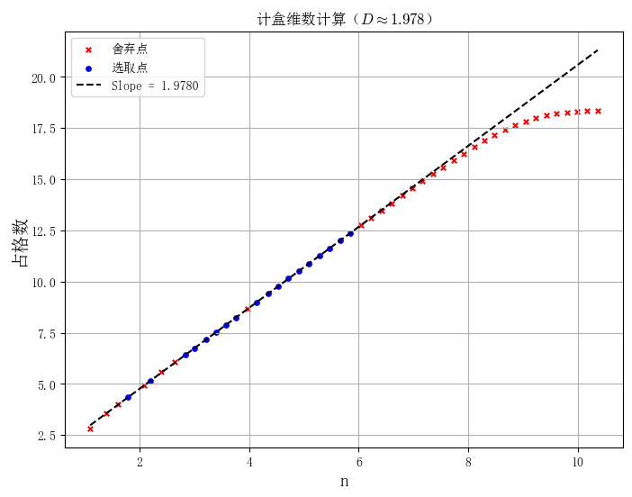

```python
fig, ax = plt.subplots(figsize=(8,6))
d0 = fit_and_plot_ransac(ax,
                         np.log(n_arr),
                         np.log(box_counts))
ax.grid()
ax.set_xlabel("n")
ax.set_ylabel("占格数")
ax.set_title(f"计盒维数计算（$D\\approx{d0:.3f}$）")
ax.legend()
display_inline(fig)
```

综上，我们计算得到的计盒维数为 $D\approx1.978$，与课件上标准李指数维数 $D_0 = 2.062$ 的偏差为：

$$ E = \frac{|2.062-1.978|}{2.062} = 4\% $$

我们有一定理由认为，对于此系统，计盒维数和李指数维数应该是相等的. 如果采样的点更多，则计算结果会更接近.

### 信息维数

根据课件，信息维数的定义如下：

$$ D = \lim_{r\to 0} \frac{S(r)}{\ln(1/r)} $$

其中 $S(r)$ 就是信息熵：

$$S(r) = -\sum_{i=1}^N p_i(r) \ln p_i (r)$$

这里 p(r) 在遍历 Hash 值过程中可以进行统计. 遍历排好序的 Hash 数值. 如果当前 Hash 值等于前一个，说明还在同一个格子里，计数器 +1；如果不同，说明换到了下一个有数据的格子，计算上一个格子的 $p(r)$ 并更新 $S$.

因此，我们可以将信息维数变为如下形式：

$$ S = D \cdot \ln(1/r) = D \cdot \ln(n) + Constant $$

通过线性拟合信息熵 $S 和分格数对数 $ln(n)$. 其斜率就是信息维数 $D$.

计算信息熵的程序实现如下：

```python
@nb.njit(parallel=True, cache=True)
def calc_entropies(traj, n_arr):
    n_pts = len(traj)
    num_n = len(n_arr)
    res = np.empty(num_n, dtype=np.float64)

    min_vals = np.empty(3, dtype=np.float64)
    max_vals = np.empty(3, dtype=np.float64)
    for k in range(3):
        min_vals[k] = np.min(traj[:, k])
        max_vals[k] = np.max(traj[:, k])
    margin = (max_vals - min_vals) * 1e-5
    min_vals -= margin
    max_vals += margin

    # 并行计算
    for i in nb.prange(num_n):
        n = int(n_arr[i])
        dx = (max_vals[0] - min_vals[0]) / n
        dy = (max_vals[1] - min_vals[1]) / n
        dz = (max_vals[2] - min_vals[2]) / n
        hashes = np.empty(n_pts, dtype=np.int64)

        for p_idx in range(n_pts):
            ix = int((traj[p_idx, 0] - min_vals[0]) / dx)
            iy = int((traj[p_idx, 1] - min_vals[1]) / dy)
            iz = int((traj[p_idx, 2] - min_vals[2]) / dz)
            if ix >= n: ix = n - 1
            if iy >= n: iy = n - 1
            if iz >= n: iz = n - 1
            hashes[p_idx] = ix + iy * n + iz * n * n
        hashes.sort()

        # 计算熵
        entropy = 0.0
        current_run_count = 1
        for k in range(1, n_pts):
            if hashes[k] == hashes[k-1]:
                current_run_count += 1
            else:
                p = current_run_count / n_pts
                entropy -= p * np.log(p)
                current_run_count = 1
        p = current_run_count / n_pts
        entropy -= p * np.log(p)
        res[i] = entropy
    return res
```

我们在 $10^{0.5}$ 到 $10^{4.5}$ 中采样 $50$ 个点（在对数空间中均匀采样）. 并计算信息熵：

```python
n_arr = np.unique(np.logspace(0.5, 4.5, num=50, dtype=int))
print("预编译")
entropies = calc_entropies(traj[:2], n_arr[:2])
t0 = time.time()
print("开始计算...")
entropies = calc_entropies(traj, n_arr)
print(f"计算结束，耗时 {time.time()-t0:.3f} s")
```

```
预编译
开始计算...
计算结束，耗时 298.114 s
```

在 log 坐标中绘制分格数和信息熵关系

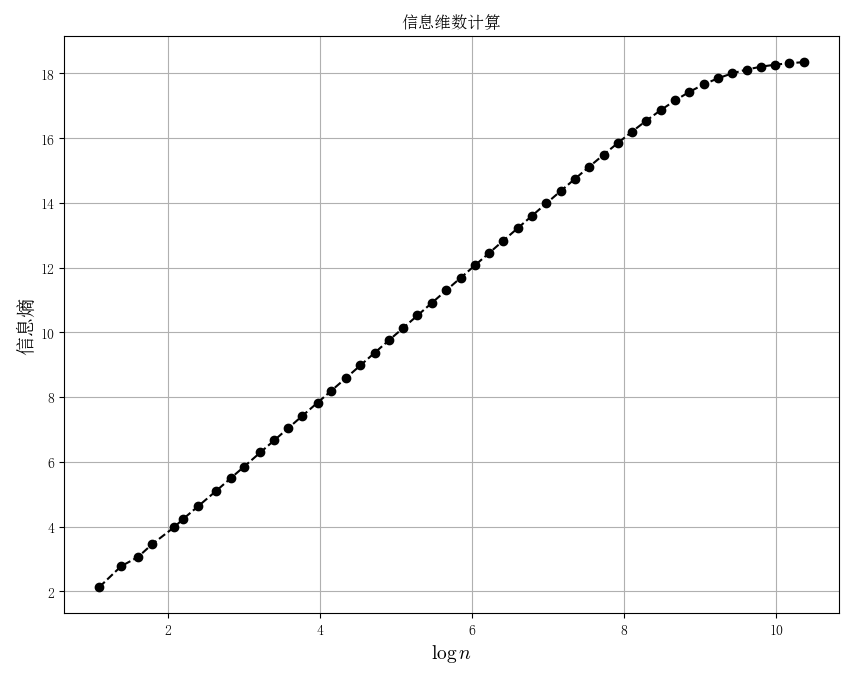

```python
fig, ax = plt.subplots(figsize=(8,6))
ax.plot(np.log(n_arr), entropies, "k--o")
ax.grid()
ax.set_xlabel("$\\log{n}$")
ax.set_ylabel("信息熵")
ax.set_title("信息维数计算")
display_inline(fig)
```

同样地，在 $n$ 较大处有“饱和现象”. 同样使用 RANSAC 方法选点拟合.

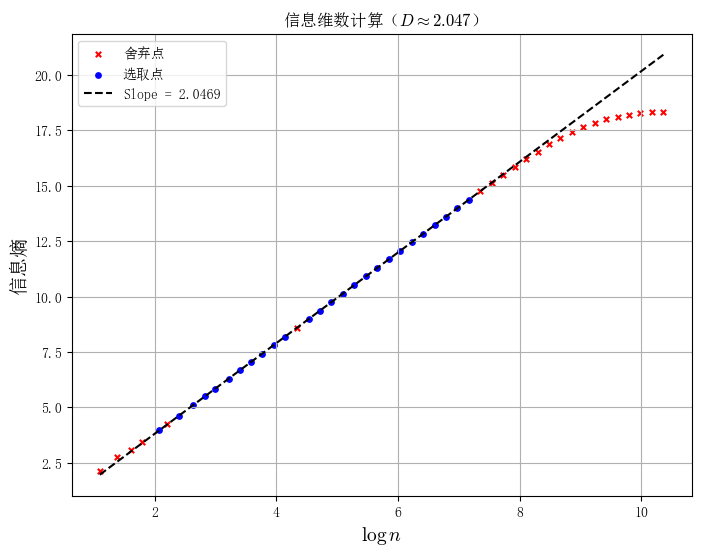

```python
fig, ax = plt.subplots(figsize=(8,6))
d0 = fit_and_plot_ransac(ax,
                         np.log(n_arr),
                         entropies)
ax.grid()
ax.set_xlabel("$\\log{n}$")
ax.set_ylabel("信息熵")
ax.set_title(f"信息维数计算（$D\\approx{d0:.3f}$）")
ax.legend()
display_inline(fig)
```

综上，我们计算得到的信息维数为 $D\approx2.047$，与课件上标准李指数维数结果 $D_0 = 2.062$ 的偏差为：

$$ E = \frac{|2.062-2.047|}{2.062} = 0.8\% $$

和李指数维数非常接近！因此我们完全有理由认为系统的信息维数和李指数维数应该是相同的.

### 关联维数

关联维数的定义如下：

$$ D = \lim_{r\to 0}\frac{\ln C(r)}{\ln r} $$

其中关联积分 $C(r)$ 为：

$$ C(r) = \lim_{N \to \infty} \frac{2}{N(N-1)} \sum_{i=1}^N \sum_{j=i+1}^N H(r-|x_i-x_j|) $$

描述了点集中距离小于 $r$ 的点对所占的比例. 这里我们通过对 $\ln C(r)$ 和 $\ln r$ 作图，其斜率即为 $D$.

这里如果我们使用双层 for 循环计算 $C(r)$. 时间复杂度为 $O(N^2)$. 效率非常低下. 这里我们可以采用计算机图形学中广泛运用的 KD-Tree 来优化（在 N 体宇宙学模拟中也被广泛运用）. 具体而言，其不断寻找某一维度的格点坐标中位数，用平面将空间一分为二. 如此循环，从而将整个 $k$ 维空间划分成多个超矩形，并且在数据结构上是一个树的结构. 当要查询距离小于 $r$ 的点时，可以在 KD-Tree 上进行减枝来加速这一过程. 从而得将时间复杂度优化为接近 $O(N \log N)$. 大幅减少计算时间.

由于 KD-Tree 实现较为复杂. 这里我直接询问了 AI 在 Python 中是否有现成的 KD-Tree 库实现. 从而知道了在 `scipy` 中有 `cKDTree` 函数，直接提供了我想要的功能. 在稍微了解后得到如下的计算关联积分的算法：

```python
def calc_correlation_sums(traj, r_arr):
    n_pts = len(traj)
    tree = cKDTree(traj)
    counts = tree.count_neighbors(tree, r_arr, cumulative=False)
    c_r = (counts.astype(np.float64) - n_pts) / (n_pts * (n_pts - 1))
    return c_r
```

由于直接对 $10^8$ 的点进行关联维数的计算太慢，因此这里将采样点集降采样，取前 $10^5$ 点进行计算.

```python
#select_idx = np.random.choice(len(traj), 100000, replace=False)
#traj_subset = traj[select_idx]
traj_subset = traj[:100000]
```

在 $10^{-1.5}$ 到 $10^{1.5}$ 中在对数空间均匀取 $r$. 并计算对应的关联积分.

```python
r_arr = np.logspace(-1.5, 1.5, 50)
t0 = time.time()
print("开始计算...")
c_r_arr = calc_correlation_sums(traj_subset, r_arr)
print(f"计算结束，耗时 {time.time()-t0:.3f} s")
```

```
开始计算...
计算结束，耗时 170.747 s
```

同样，我们使用 RANSAC 方法进行线性拟合.

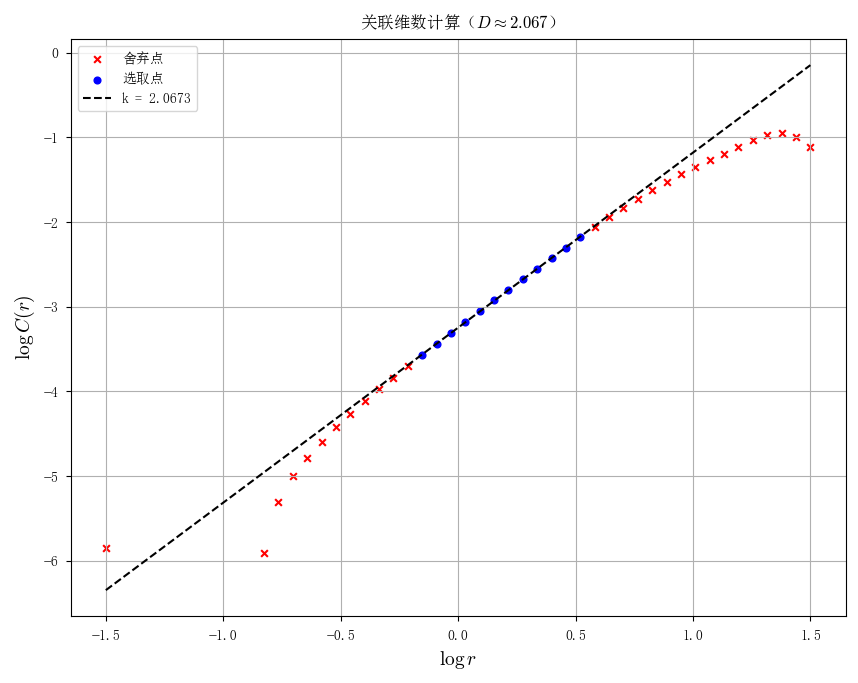

```python
fig, ax = plt.subplots(figsize=(8,6))
valid_mask = (r_arr > 0) & (c_r_arr > 0) # 排除无效点
r_arr = r_arr[valid_mask]
c_r_arr = c_r_arr[valid_mask]
d0 = fit_and_plot_ransac(ax,
                         np.log10(r_arr),
                         np.log10(c_r_arr),
                         res_threshold=0.01)
ax.grid()
ax.set_xlabel("$\\log{r}$")
ax.set_ylabel("$\\log C(r)$")
ax.set_title(f"关联维数计算（$D\\approx{d0:.3f}$）")
ax.legend()
display_inline(fig)
```

综上，我们计算得到的关联维数为 $D\approx2.067$，与课件上标准李指数维数结果 $D_0 = 2.062$ 的偏差为：

$$ E = \frac{|2.067-2.062|}{2.062} = 0.3\% $$

和李指数维数非常接近！因此我们完全有理由认为系统的关联维数和李指数维数应该是相同的.

同时，我们还可以注意到，在计算关联维数时，除了在 $r$ 小的时候出现“饱和”现象（这里横坐标是 $r$，$r$ 小对应前面 $n$ 大，因此是 $r$ 小是以往的“饱和”现象）在 $r$ 大时还会出现“弯曲”. 这是因为吸引子是在某一个有限的区域内的，并不是完全平铺在所有空间内的，因此当 $r$ 较大时会出现偏差.

## The Mandelbrot Set

### 绘制

Mandelbrot Set 从如下迭代公式得到：

$$ z_{n+1} = z_n^2 + c, \quad z_0 = 0 $$

如果 $z_n$ 跑到无穷远，则不属于 Mandelbrot Set. 反之属于 Mandelbrot Set.

对于空间中每一个点，我们迭代 $1000$ 次，如果 $|z_n|>2$ 则认为发散到无穷远. 并行化的计算函数如下：

```python
@nb.njit(parallel=True, cache=True)
def calc_mandelbrot(xmin, xmax, ymin, ymax, width, height, max_iter):
    is_esc_map = np.zeros((height, width), dtype=np.int32)
    dx = (xmax - xmin) / width
    dy = (ymax - ymin) / height
    for y in nb.prange(height):
        for x in range(width):
            c = complex(xmin + x * dx, ymin + y * dy)
            z = 0j
            is_esc = False
            for i in range(max_iter):
                if z.real*z.real + z.imag*z.imag > 4.0:
                    is_esc = True
                    break
                z = z*z + c
            if is_esc:
                is_esc_map[y, x] = 1
    return is_esc_map
```

如果发散到无穷远，则染黑色. 反之则染白色. 如下：

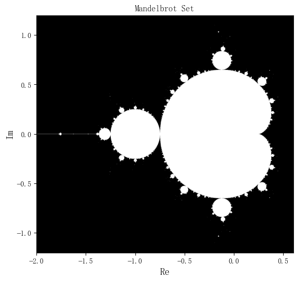

```python
width, height = 1600, 1400
xmin, xmax = -2.0, 0.6
ymin, ymax = -1.2, 1.2
max_iter = 1000
tol = 1e-4
max_period = 12

is_esc_map = calc_mandelbrot(xmin, xmax, ymin, ymax, width, height, max_iter)

fig, ax = plt.subplots(figsize=(8, 6))
im_escape = ax.imshow(is_esc_map, extent=[xmin, xmax, ymin, ymax],cmap='gray_r', origin='lower')
ax.set_title(f"Mandelbrot Set")
ax.set_xlabel("Re")
ax.set_ylabel("Im")
display_inline(fig)
```

可见我们得到一个经典的 The Mandelbrot Set 图像.

### 不同区域发散速度

下面我们分析在 Mandelbrot Set 外不同区域的发散速度. 我们记录 $|z_n|>2$ 时的 $n$. 并通过颜色展示，如下：

```python
@nb.njit(parallel=True, cache=True)
def calc_mandelbrot_esc(xmin, xmax, ymin, ymax, width, height, max_iter):
    esc_map = np.zeros((height, width), dtype=np.int32)
    dx = (xmax - xmin) / width
    dy = (ymax - ymin) / height
    for y in nb.prange(height):
        for x in range(width):
            c = complex(xmin + x * dx, ymin + y * dy)
            z = 0j
            iter_count = max_iter
            for i in range(max_iter):
                if z.real*z.real + z.imag*z.imag > 4.0:
                    iter_count = i
                    break
                z = z*z + c
            esc_map[y, x] = iter_count
    return esc_map
```

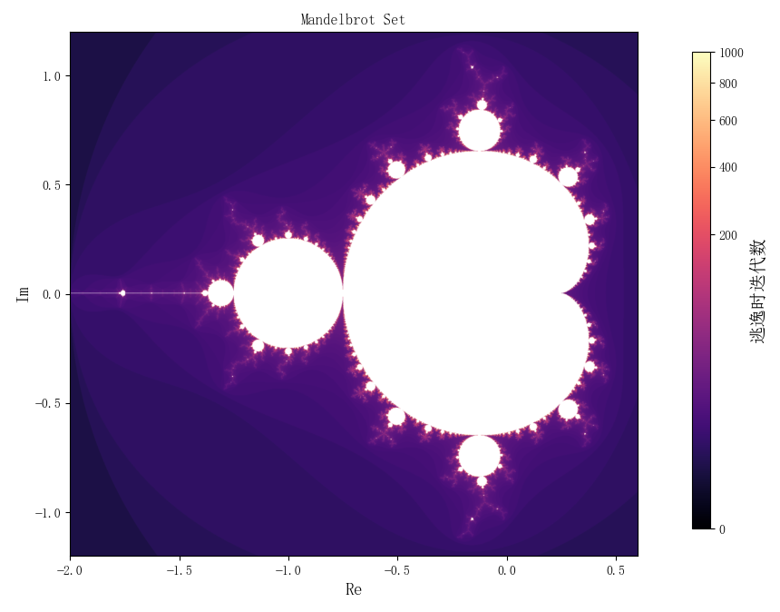

```python
width, height = 1600, 1400
xmin, xmax = -2.0, 0.6
ymin, ymax = -1.2, 1.2
max_iter = 1000
tol = 1e-4
max_period = 12

esc_map = calc_mandelbrot_esc(xmin, xmax, ymin, ymax, width, height, max_iter)

fig, ax = plt.subplots(figsize=(8, 6))
mask_escape = np.ma.masked_equal(esc_map, max_iter)

cmap_esc = plt.cm.magma.copy()
cmap_esc.set_bad('white')

norm_esc = mpl.colors.PowerNorm(gamma=0.3, vmin=0, vmax=max_iter)

im_escape = ax.imshow(mask_escape, extent=[xmin, xmax, ymin, ymax],
                      cmap=cmap_esc, norm=norm_esc, origin='lower', interpolation='bilinear')

plt.subplots_adjust(right=0.85)
cax = fig.add_axes([0.86, 0.15, 0.02, 0.7])
cbar = plt.colorbar(im_escape, cax=cax)
cbar.set_label("逃逸时迭代数")

ax.set_title(f"Mandelbrot Set")
ax.set_xlabel("Re")
ax.set_ylabel("Im")

display_inline(fig)
```

这里颜色越深，则逃逸时迭代次数越小，逃逸速度越快. 这里可见逃逸速度整体是越远离 Mandelbrot Set 边界越快（逃逸时迭代次数越低）

### 不同区域收敛轨道周期

如果我们判断点是不逃逸到无穷远的（也就是 Mandelbrot Set 里面的点），我们尝试搜索其中的稳定周期轨道是周期几. 我们记录经过 1000 次迭代后的值 $z_n$. 再进行 12 次迭代，每计算一次 $z_{n+i}$ 就检查和 $z_n$ 是否相同（小于设定 $10^{-4}$ 容差）. 从而得到周期. 这里我们再添加一个颜色条显示 Mandelbrot Set 内部的周期数：

```python
@nb.njit(parallel=True, cache=True)
def calc_mandelbrot_with_esc_and_per(xmin, xmax, ymin, ymax, width, height, max_iter, tol, max_period):
    esc_map = np.zeros((height, width), dtype=np.int32)
    per_map = np.zeros((height, width), dtype=np.int32)
    dx = (xmax - xmin) / width
    dy = (ymax - ymin) / height
    for y in nb.prange(height):
        for x in range(width):
            c = complex(xmin + x * dx, ymin + y * dy)
            z = 0j
            is_esc = False
            iter_count = 0
            for i in range(max_iter):
                if z.real*z.real + z.imag*z.imag > 4.0:
                    is_esc = True
                    iter_count = i
                    break
                z = z*z + c
            if is_esc:
                esc_map[y, x] = iter_count
                per_map[y, x] = 0
            else:
                esc_map[y, x] = max_iter
                z0 = z  # 记录当前稳定状态
                found_p = -1    # 默认 -1 (代表未知周期或高阶周期)
                for p in range(1, max_period + 1):
                    z = z*z + c
                    if abs(z - z0) < tol:
                        found_p = p
                        break
                per_map[y, x] = found_p
    return esc_map, per_map

width, height = 1600, 1400
xmin, xmax = -2.0, 0.6
ymin, ymax = -1.2, 1.2
max_iter = 1000
tol = 1e-4
max_period = 12

esc_map, per_map = calc_mandelbrot_with_esc_and_per(
    xmin, xmax, ymin, ymax, width, height, max_iter, tol, max_period
)
```

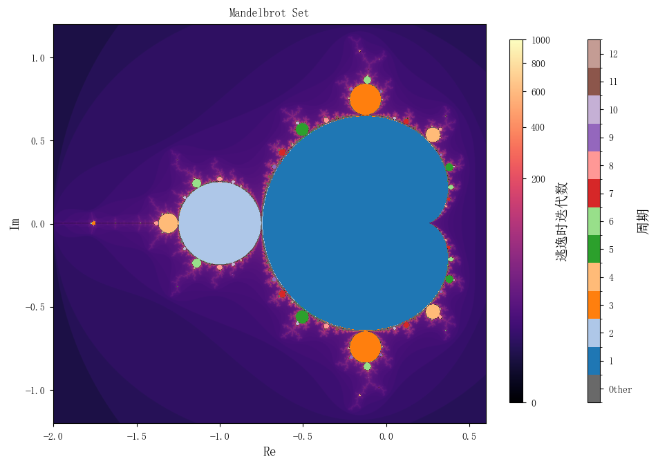

```python
fig, ax = plt.subplots(figsize=(10, 6))

# 第一层绘制（逃逸速度）
mask_escape = np.ma.masked_equal(esc_map, max_iter)
cmap_esc = plt.cm.magma.copy()
cmap_esc.set_bad('black')
norm_esc = mpl.colors.PowerNorm(gamma=0.3, vmin=0, vmax=max_iter)
im_escape = ax.imshow(mask_escape, extent=[xmin, xmax, ymin, ymax],
                      cmap=cmap_esc, norm=norm_esc, origin='lower', interpolation='bilinear')

# 第二层绘制（周期）
mask_period = np.ma.masked_equal(per_map, 0)
base_colors = plt.cm.tab20.colors
color_list = ['dimgray'] + list(base_colors[:max_period])
cmap_period = mpl.colors.ListedColormap(color_list)
viz_period_data = per_map.copy()
viz_period_data[viz_period_data == -1] = 0

bounds = np.arange(-0.5, max_period + 1.5, 1)
norm_period = mpl.colors.BoundaryNorm(bounds, cmap_period.N)

im_period = ax.imshow(mask_period, extent=[xmin, xmax, ymin, ymax],
                      cmap=cmap_period, norm=norm_period, origin='lower', interpolation='nearest')

plt.subplots_adjust(right=0.82)

cax1 = fig.add_axes([0.75, 0.15, 0.015, 0.7])
cbar1 = plt.colorbar(im_escape, cax=cax1)
cbar1.set_label("逃逸时迭代数")

cax2 = fig.add_axes([0.84, 0.15, 0.015, 0.7])
cbar2 = plt.colorbar(im_period, cax=cax2, ticks=np.arange(0, max_period + 1))
labels = ["Other"] + [str(i) for i in range(1, max_period + 1)]
cbar2.ax.set_yticklabels(labels)
cbar2.set_label("周期")

ax.set_title("Mandelbrot Set")
ax.set_xlabel("Re")
ax.set_ylabel("Im")
display_inline(fig)
```

从中我们可以看出，Mandelbrot Set 内部的稳定的周期轨道的分布很有规律，在每一个“大区域”内其稳定轨道的周期数均相同.

## 周期一，二，五轨道

从上图中我们很容易得到内部周期轨道的分布. 我们可以从中一些点来验证这些区域确实是对应的周期轨道.

此章节中所有取的验证的点均在下图中标注（取点是在对应区域中随机挑的）

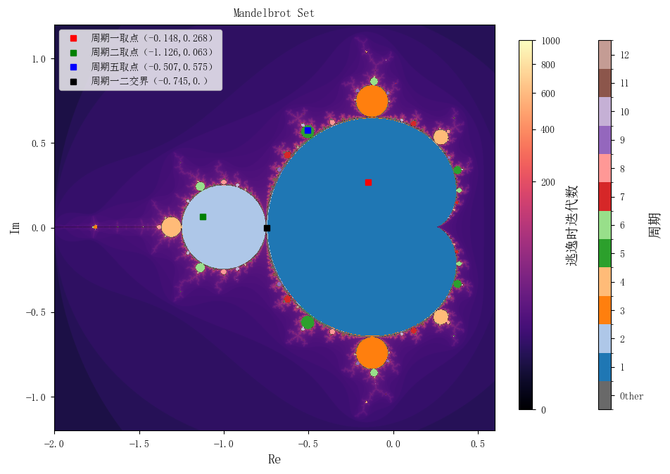

```python
width, height = 1600, 1400
xmin, xmax = -2.0, 0.6
ymin, ymax = -1.2, 1.2
max_iter = 1000
tol = 1e-4
max_period = 12

esc_map, per_map = calc_mandelbrot_with_esc_and_per(
    xmin, xmax, ymin, ymax, width, height, max_iter, tol, max_period
)

fig, ax = plt.subplots(figsize=(10, 6))

# 第一层绘制（逃逸速度）
mask_escape = np.ma.masked_equal(esc_map, max_iter)
cmap_esc = plt.cm.magma.copy()
cmap_esc.set_bad('black')
norm_esc = mpl.colors.PowerNorm(gamma=0.3, vmin=0, vmax=max_iter)
im_escape = ax.imshow(mask_escape, extent=[xmin, xmax, ymin, ymax],
                      cmap=cmap_esc, norm=norm_esc, origin='lower', interpolation='bilinear')

# 第二层绘制（周期）
mask_period = np.ma.masked_equal(per_map, 0)
base_colors = plt.cm.tab20.colors
color_list = ['dimgray'] + list(base_colors[:max_period])
cmap_period = mpl.colors.ListedColormap(color_list)
viz_period_data = per_map.copy()
viz_period_data[viz_period_data == -1] = 0

bounds = np.arange(-0.5, max_period + 1.5, 1)
norm_period = mpl.colors.BoundaryNorm(bounds, cmap_period.N)

im_period = ax.imshow(mask_period, extent=[xmin, xmax, ymin, ymax],
                      cmap=cmap_period, norm=norm_period, origin='lower', interpolation='nearest')

plt.subplots_adjust(right=0.82)

cax1 = fig.add_axes([0.75, 0.15, 0.015, 0.7])
cbar1 = plt.colorbar(im_escape, cax=cax1)
cbar1.set_label("逃逸时迭代数")

cax2 = fig.add_axes([0.84, 0.15, 0.015, 0.7])
cbar2 = plt.colorbar(im_period, cax=cax2, ticks=np.arange(0, max_period + 1))
labels = ["Other"] + [str(i) for i in range(1, max_period + 1)]
cbar2.ax.set_yticklabels(labels)
cbar2.set_label("周期")

# 标记点
ax.plot(-0.148, 0.268, "rs" ,label="周期一取点（-0.148,0.268）")
ax.plot(-1.126, 0.063, "gs" ,label="周期二取点（-1.126,0.063）")
ax.plot(-0.507, 0.575, "bs" ,label="周期五取点（-0.507,0.575）")
ax.plot(-0.745, 0.0, "ks" ,label="周期一二交界（-0.745,0.）")

ax.set_title("Mandelbrot Set")
ax.set_xlabel("Re")
ax.set_ylabel("Im")
ax.legend(loc="upper left")
display_inline(fig)
```

### 周期一

对于周期一，取 $ C=-0.148+0.268i $，根据 Mandelbrot Set 的要求，取迭代初始值 $z_0 = 0$，系统的迭代过程如下（分为虚部和实部）：

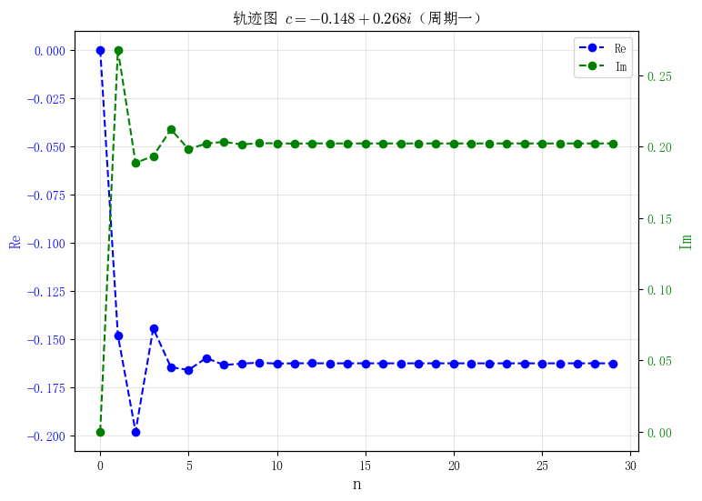

```python
@nb.njit(cache=True)
def calc_trajectory(c,n):
    z = 0j
    traj = np.empty(n, dtype=np.complex64)
    for i in range(n):
        traj[i] = z
        z = z*z+c
    return traj

c = -0.148 + 0.268j
n = 30
traj = calc_trajectory(c, n)
n_arr = np.arange(n)

traj_re = traj.real
traj_im = traj.imag

fig, ax1 = plt.subplots(figsize=(8, 6))

line_re = ax1.plot(n_arr, traj_re, "b--o", label='Re')
ax1.set_ylabel('Re', color="b", fontsize=12)
ax1.tick_params(axis='y', labelcolor="b")
ax1.set_xlabel('n')

ax2 = ax1.twinx()
line_im = ax2.plot(n_arr, traj_im, "g--o", label='Im')
ax2.set_ylabel("Im", color="g")
ax2.tick_params(axis='y', labelcolor="g")
ax1.set_title(f"轨迹图 $c = {c.real:.3f} + {c.imag:.3f}i$（周期一）")

ax1.grid(True, alpha=0.3)
lines = line_re + line_im
labels = [l.get_label() for l in lines]
ax1.legend(lines, labels, loc='best', frameon=True, fancybox=True)
#plt.tight_layout()
display_inline(fig)
```

我们也可以在复平面中绘制轨迹，通过颜色表示迭代步数.

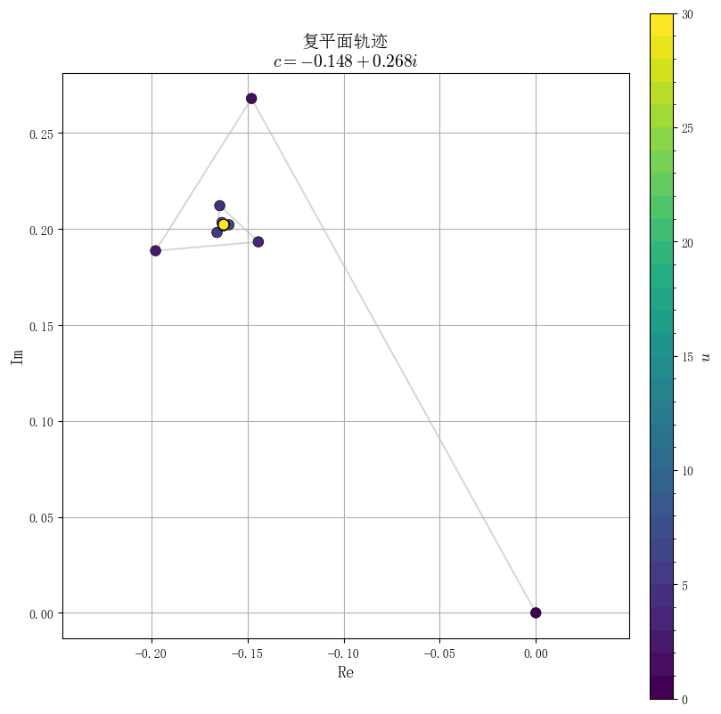

```python
n_arr = np.arange(n)
fig, ax = plt.subplots(figsize=(10, 10))
cmap = plt.get_cmap('viridis', n)
bounds = np.arange(n + 1)
norm = mpl.colors.BoundaryNorm(bounds, cmap.N)

ax.plot(traj.real, traj.imag, c='gray', alpha=0.3, zorder=1)
sc = ax.scatter(traj.real, traj.imag, c=n_arr,
                cmap=cmap, norm=norm,
                s=70, edgecolor='k', linewidth=0.5, zorder=2)
cbar = fig.colorbar(sc, ax=ax, pad=0.03, aspect=30, ticks=np.arange(0, n+1, 5))

cbar.set_label('$n$', fontsize=12, rotation=270, labelpad=15)
ax.set_title(f"复平面轨迹\n$c = {c.real:.3f} + {c.imag:.3f}i$", fontsize=14)
ax.set_xlabel("Re")
ax.set_ylabel("Im")
ax.grid()
ax.set_aspect('equal')
ax.set_box_aspect(1)
display_inline(fig)
```

可见最后确实是稳定的周期一轨道.

### 周期二

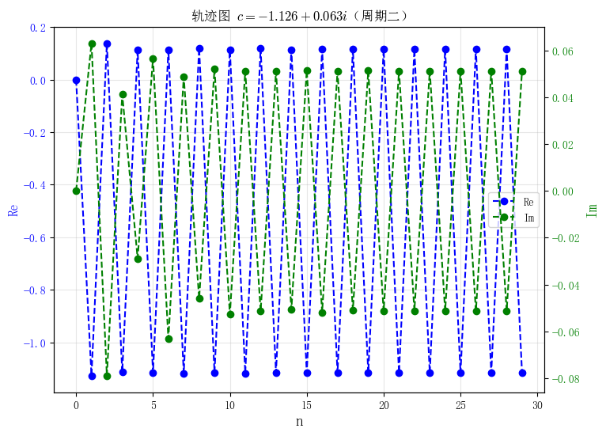

```python
c = -1.126 + 0.063j
n = 30
traj = calc_trajectory(c, n)
n_arr = np.arange(n)

traj_re = traj.real
traj_im = traj.imag

fig, ax1 = plt.subplots(figsize=(8, 6))

line_re = ax1.plot(n_arr, traj_re, "b--o", label='Re')
ax1.set_ylabel('Re', color="b", fontsize=12)
ax1.tick_params(axis='y', labelcolor="b")
ax1.set_xlabel('n')

ax2 = ax1.twinx()
line_im = ax2.plot(n_arr, traj_im, "g--o", label='Im')
ax2.set_ylabel("Im", color="g")
ax2.tick_params(axis='y', labelcolor="g")
ax1.set_title(f"轨迹图 $c = {c.real:.3f} + {c.imag:.3f}i$（周期二）")

ax1.grid(True, alpha=0.3)
lines = line_re + line_im
labels = [l.get_label() for l in lines]
ax1.legend(lines, labels, loc='best', frameon=True, fancybox=True)
#plt.tight_layout()
display_inline(fig)
```

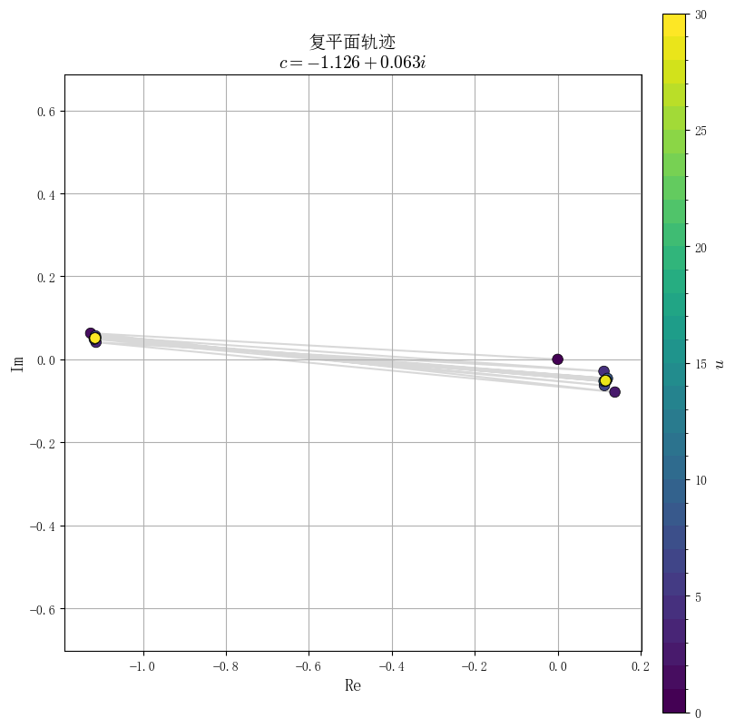

```python
n_arr = np.arange(n)
fig, ax = plt.subplots(figsize=(10, 10))
cmap = plt.get_cmap('viridis', n)
bounds = np.arange(n + 1)
norm = mpl.colors.BoundaryNorm(bounds, cmap.N)

ax.plot(traj.real, traj.imag, c='gray', alpha=0.3, zorder=1)
sc = ax.scatter(traj.real, traj.imag, c=n_arr,
                cmap=cmap, norm=norm,
                s=70, edgecolor='k', linewidth=0.5, zorder=2)
cbar = fig.colorbar(sc, ax=ax, pad=0.03, aspect=30, ticks=np.arange(0, n+1, 5))

cbar.set_label('$n$', fontsize=12, rotation=270, labelpad=15)
ax.set_title(f"复平面轨迹\n$c = {c.real:.3f} + {c.imag:.3f}i$", fontsize=14)
ax.set_xlabel("Re")
ax.set_ylabel("Im")
ax.grid()
ax.set_aspect('equal')
ax.set_box_aspect(1)
display_inline(fig)
```

可见最后确实是稳定的周期二轨道.

### 周期五

对于周期五，取 $ C=-0.507 + 0.575i $，根据 Mandelbrot Set 的要求，取迭代初始值 $z_0 = 0$，系统的迭代过程如下（分为虚部和实部）：

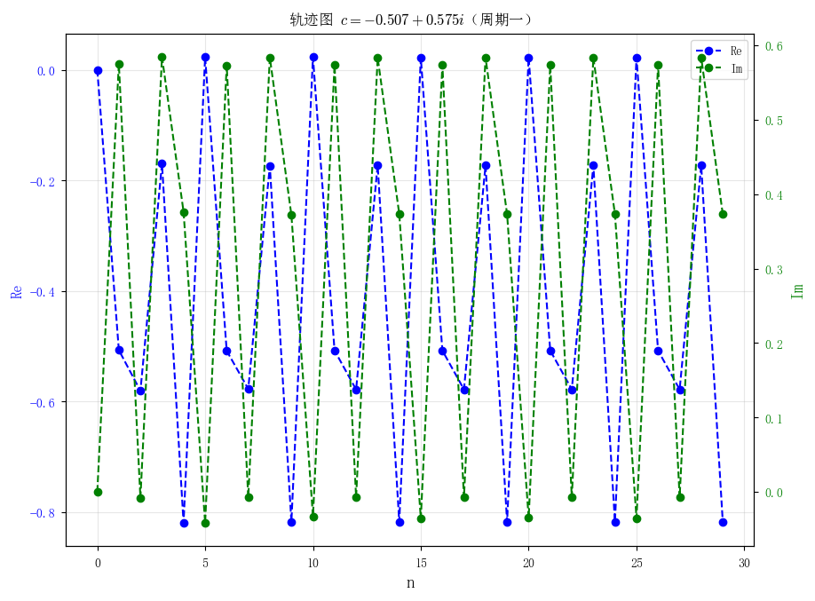

```python
c = -0.507 + 0.575j
n = 30
traj = calc_trajectory(c, n)
n_arr = np.arange(n)

traj_re = traj.real
traj_im = traj.imag

fig, ax1 = plt.subplots(figsize=(8, 6))

line_re = ax1.plot(n_arr, traj_re, "b--o", label='Re')
ax1.set_ylabel('Re', color="b", fontsize=12)
ax1.tick_params(axis='y', labelcolor="b")
ax1.set_xlabel('n')

ax2 = ax1.twinx()
line_im = ax2.plot(n_arr, traj_im, "g--o", label='Im')
ax2.set_ylabel("Im", color="g")
ax2.tick_params(axis='y', labelcolor="g")
ax1.set_title(f"轨迹图 $c = {c.real:.3f} + {c.imag:.3f}i$（周期一）")

ax1.grid(True, alpha=0.3)
lines = line_re + line_im
labels = [l.get_label() for l in lines]
ax1.legend(lines, labels, loc='best', frameon=True, fancybox=True)
#plt.tight_layout()
display_inline(fig)
```

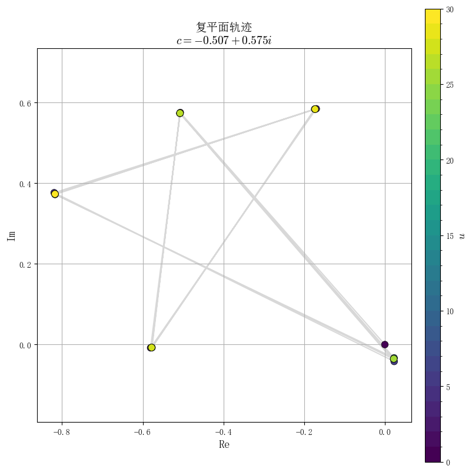

```python
n_arr = np.arange(n)
fig, ax = plt.subplots(figsize=(10, 10))
cmap = plt.get_cmap('viridis', n)
bounds = np.arange(n + 1)
norm = mpl.colors.BoundaryNorm(bounds, cmap.N)

ax.plot(traj.real, traj.imag, c='gray', alpha=0.3, zorder=1)
sc = ax.scatter(traj.real, traj.imag, c=n_arr,
                cmap=cmap, norm=norm,
                s=70, edgecolor='k', linewidth=0.5, zorder=2)
cbar = fig.colorbar(sc, ax=ax, pad=0.03, aspect=30, ticks=np.arange(0, n+1, 5))

cbar.set_label('$n$', fontsize=12, rotation=270, labelpad=15)
ax.set_title(f"复平面轨迹\n$c = {c.real:.3f} + {c.imag:.3f}i$", fontsize=14)
ax.set_xlabel("Re")
ax.set_ylabel("Im")
ax.grid()
ax.set_aspect('equal')
ax.set_box_aspect(1)
display_inline(fig)
```

可见这里最后确实是稳定的周期五轨道.

### 临界慢化

这里我们考虑在周期一和周期二边界的分界点：

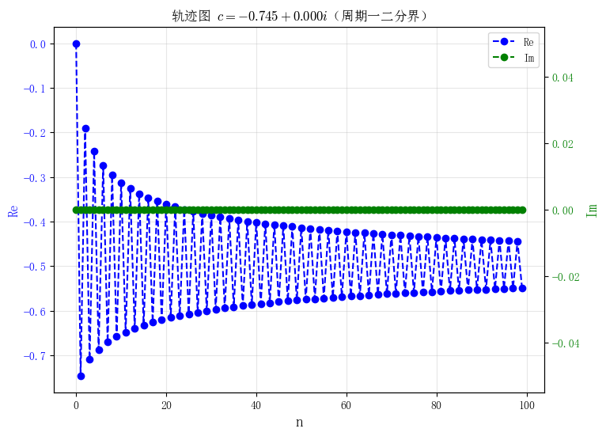

```python
c = -0.7454 + 0.j
n = 100
traj = calc_trajectory(c, n)
n_arr = np.arange(n)

traj_re = traj.real
traj_im = traj.imag

fig, ax1 = plt.subplots(figsize=(8, 6))

line_re = ax1.plot(n_arr, traj_re, "b--o", label='Re')
ax1.set_ylabel('Re', color="b", fontsize=12)
ax1.tick_params(axis='y', labelcolor="b")
ax1.set_xlabel('n')

ax2 = ax1.twinx()
line_im = ax2.plot(n_arr, traj_im, "g--o", label='Im')
ax2.set_ylabel("Im", color="g")
ax2.tick_params(axis='y', labelcolor="g")
ax1.set_title(f"轨迹图 $c = {c.real:.3f} + {c.imag:.3f}i$（周期一二分界）")

ax1.grid(True, alpha=0.3)
lines = line_re + line_im
labels = [l.get_label() for l in lines]
ax1.legend(lines, labels, loc='best', frameon=True, fancybox=True)
#plt.tight_layout()
display_inline(fig)
```

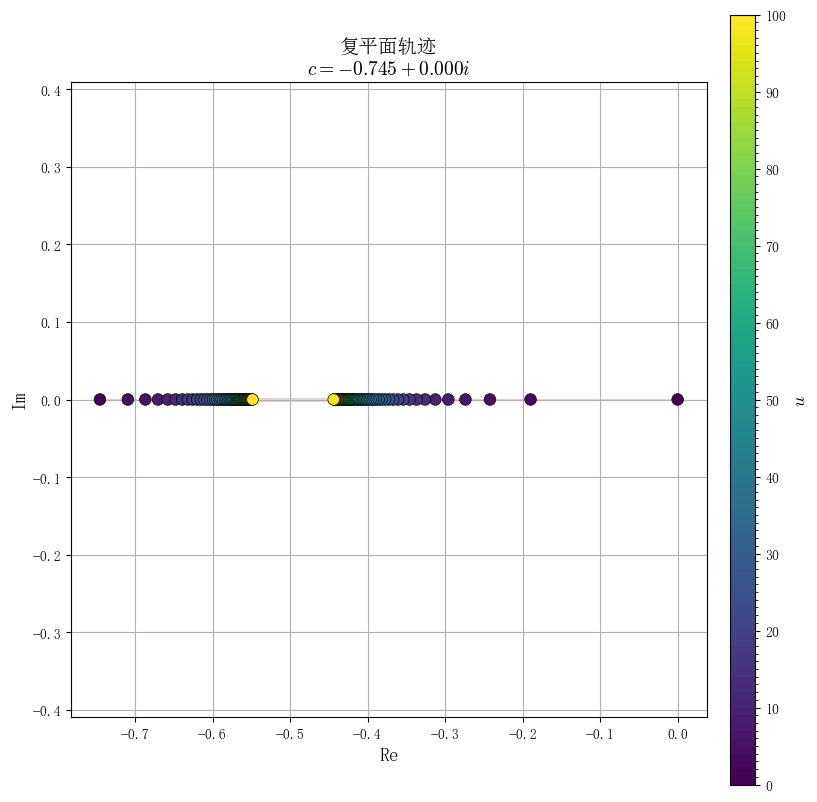

```python
n_arr = np.arange(n)
fig, ax = plt.subplots(figsize=(10, 10))
cmap = plt.get_cmap('viridis', n)
bounds = np.arange(n + 1)
norm = mpl.colors.BoundaryNorm(bounds, cmap.N)

ax.plot(traj.real, traj.imag, c='gray', alpha=0.3, zorder=1)
sc = ax.scatter(traj.real, traj.imag, c=n_arr,
                cmap=cmap, norm=norm,
                s=70, edgecolor='k', linewidth=0.5, zorder=2)
cbar = fig.colorbar(sc, ax=ax, pad=0.03, aspect=30, ticks=np.arange(0, n+1, 10))

cbar.set_label('$n$', fontsize=12, rotation=270, labelpad=15)
ax.set_title(f"复平面轨迹\n$c = {c.real:.3f} + {c.imag:.3f}i$", fontsize=14)
ax.set_xlabel("Re")
ax.set_ylabel("Im")
ax.grid()
ax.set_aspect('equal')
ax.set_box_aspect(1)
display_inline(fig)
```

可见其收敛速度明显变慢，呈现临界慢化现象. 和以往的经验是相同的.

## 分叉图

### 沿实轴分叉图

现在根据作业要求，我们绘制沿实轴的分叉图，绘制分叉图的算法在第三次作业中已经用过，在此不再赘述. 绘制得到的分叉图如下：

```python
@nb.njit(parallel=True)
def calc_bifurcation_pt(c_real, c_imag, skip_n, save_n):
    n = len(c_real)
    tot_pt = n * save_n

    out_x = np.empty(tot_pt, dtype=np.float32)
    out_y = np.empty(tot_pt, dtype=np.float32)
    out_z_real = np.empty(tot_pt, dtype=np.float32)
    for i in nb.prange(n):
        c = complex(c_real[i], c_imag[i])
        z = 0j
        for _ in range(skip_n):
            z = z*z + c
        base_idx = i * save_n
        for k in range(save_n):
            z = z*z + c
            out_x[base_idx + k] = c.real
            out_y[base_idx + k] = c.imag
            out_z_real[base_idx + k] = z.real
    return out_x, out_y, out_z_real
```

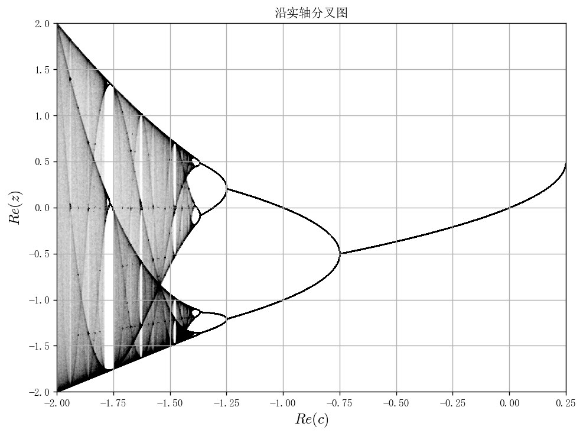

```python
c_min, c_max = -2.0, 0.25
n_res = 10000
skip_n = 5000
save_n = 1000

c_reals = np.linspace(c_min, c_max, n_res)
c_imags = np.zeros(n_res)
bif_c, _, bif_z = calc_bifurcation_pt(c_reals, c_imags, skip_n, save_n)

fig, ax = plt.subplots(figsize=(8, 6))
ax.scatter(bif_c, bif_z, s=0.05, c='k', alpha=0.02, marker='.')
ax.set_title(r"沿实轴分叉图")
ax.set_xlabel(r"$Re(c)$")
ax.set_ylabel(r"$Re(z)$")
ax.set_xlim(c_min, c_max)
ax.set_ylim(-2, 2)
ax.grid()
plt.tight_layout()
display_inline(fig)
```

可见其呈现出类似 Logistic 映射分叉图的类似的结构.

这里我们将分叉图和前文得到的 Mandelbrot Set 图像进行对比. 并标注分叉点，得到：

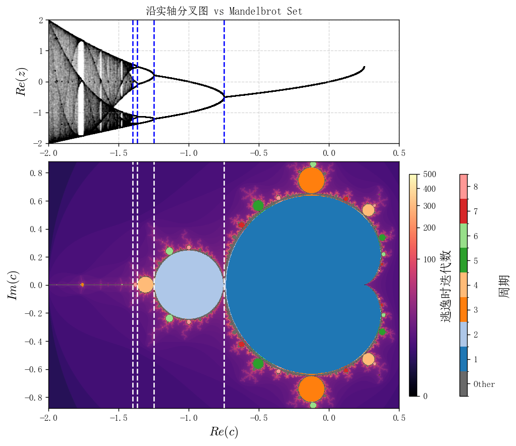

```python
common_xmin, common_xmax = -2.0, 0.5
n_res_bif = 2000
skip_n = 2000
save_n = 500
c_reals = np.linspace(common_xmin, common_xmax, n_res_bif)
c_imags = np.zeros(n_res_bif)
bif_c, _, bif_z = calc_bifurcation_pt(c_reals, c_imags, skip_n, save_n)

ymin, ymax = -1.1, 1.1
width, height = 1200, 1000
max_iter = 500
tol = 1e-4
max_period = 8

esc_map, per_map = calc_mandelbrot_with_esc_and_per(
    common_xmin, common_xmax, ymin, ymax, width, height, max_iter, tol, max_period
)

bifurcation_lines = [-0.75, -1.25, -1.3680989, -1.401155]

fig = plt.figure(figsize=(8, 8))
gs = fig.add_gridspec(2, 1, height_ratios=[1, 2], hspace=0.1)
ax1 = fig.add_subplot(gs[0, 0])
ax2 = fig.add_subplot(gs[1, 0], sharex=ax1) # 共享 X 轴

ax1.scatter(bif_c, bif_z, s=0.05, c='k', alpha=0.1, marker='.')

ax1.set_ylabel(r"$Re(z)$")
ax1.set_ylim(-2, 2)
ax1.grid(True, which='both', linestyle='--', alpha=0.5)
ax1.set_title("沿实轴分叉图 vs Mandelbrot Set")
mask_escape = np.ma.masked_equal(esc_map, max_iter)
cmap_esc = plt.cm.magma.copy()
cmap_esc.set_bad('black')
norm_esc = mpl.colors.PowerNorm(gamma=0.3, vmin=0, vmax=max_iter)
im_escape = ax2.imshow(mask_escape, extent=[common_xmin, common_xmax, ymin, ymax],
                      cmap=cmap_esc, norm=norm_esc, origin='lower', interpolation='bilinear')

mask_period = np.ma.masked_equal(per_map, 0)
base_colors = plt.cm.tab20.colors
color_list = ['dimgray'] + list(base_colors[:max_period])
cmap_period = mpl.colors.ListedColormap(color_list)
viz_period_data = per_map.copy()
viz_period_data[viz_period_data == -1] = 0

bounds = np.arange(-0.5, max_period + 1.5, 1)
norm_period = mpl.colors.BoundaryNorm(bounds, cmap_period.N)

im_period = ax2.imshow(mask_period, extent=[common_xmin, common_xmax, ymin, ymax],
                      cmap=cmap_period, norm=norm_period, origin='lower', interpolation='nearest')

ax2.set_xlabel(r"$Re(c)$")
ax2.set_ylabel(r"$Im(c)$")
ax2.set_aspect('equal', adjustable='datalim')
for x_pos in bifurcation_lines:
    ax1.axvline(x=x_pos, color='b', linestyle='--')
    ax2.axvline(x=x_pos, color='w', linestyle='--')
plt.subplots_adjust(right=0.82)
pos2 = ax2.get_position()

cbar_height = pos2.height * 0.9
cbar_bottom = pos2.y0 + (pos2.height - cbar_height) / 2

cax1 = fig.add_axes([0.84, cbar_bottom, 0.015, cbar_height])
cbar1 = plt.colorbar(im_escape, cax=cax1)
cbar1.set_label("逃逸时迭代数")

cax2 = fig.add_axes([0.94, cbar_bottom, 0.015, cbar_height])
cbar2 = plt.colorbar(im_period, cax=cax2, ticks=np.arange(0, max_period + 1))
labels = ["Other"] + [str(i) for i in range(1, max_period + 1)]
cbar2.ax.set_yticklabels(labels)
cbar2.set_label("周期")

display_inline(fig)
```

可见，分叉图的每一个分叉点都对应下面 Mandelbrot Set 中的每一个“大区域”的分界. 同时，混沌出现在 Mandelblot Set 中的“线状”结构. 同时，在“线”中的小的 Mandelbrot 图形对应混沌中的周期窗口（比如周期三在 Mandelbrot Set 中对应一个小的“岛”，同时隐约可见其也是 Mandelbrot Set 的结构.）

### 二维平面分叉图

现在我们进一步绘制在整个二维平面上的分叉图. 这里由于周期轨道是复数. 我们只记录其实部. 从而绘制参数 $c$ 在平面内的分叉图.

这里由于 `Matplotlib` 3D 绘图太慢，这里使用计算机图形学中的“体素”的方法来降低需要绘制的点数，从而加速 Matplotlib 绘制. 具体而言，这里将空间划分网格，如果有多个点在同一个方格内，则简化只绘制一个点. 这里此函数直接由 AI 生成，并经过检测和修改使得更符合绘制需求. 同时为了方便也不再使用前文 Hash 方法优化.

```python
@nb.njit(parallel=False)
def vox_pt(xs, ys, zs, values, bounds, grid_dims):
    xmin, xmax, ymin, ymax, zmin, zmax = bounds
    nx, ny, nz = grid_dims

    count_grid = np.zeros((nx, ny, nz), dtype=np.int32)
    value_grid = np.zeros((nx, ny, nz), dtype=np.float32)

    n_points = len(xs)
    dx = (xmax - xmin)
    dy = (ymax - ymin)
    dz = (zmax - zmin)

    for i in range(n_points):
        x, y, z, v = xs[i], ys[i], zs[i], values[i]

        if not (xmin <= x < xmax and ymin <= y < ymax and zmin <= z < zmax):
            continue

        idx_x = int((x - xmin) / dx * nx)
        idx_y = int((y - ymin) / dy * ny)
        idx_z = int((z - zmin) / dz * nz)

        if idx_x >= nx: idx_x = nx - 1
        if idx_y >= ny: idx_y = ny - 1
        if idx_z >= nz: idx_z = nz - 1

        count_grid[idx_x, idx_y, idx_z] += 1
        value_grid[idx_x, idx_y, idx_z] += v

    valid_count = 0
    flat_len = nx * ny * nz
    for i in range(flat_len):
        if count_grid.flat[i] > 0:
            valid_count += 1

    out_vx = np.empty(valid_count, dtype=np.float32)
    out_vy = np.empty(valid_count, dtype=np.float32)
    out_vz = np.empty(valid_count, dtype=np.float32)
    out_vcolor = np.empty(valid_count, dtype=np.float32)
    ptr = 0
    for ix in range(nx):
        center_x = xmin + (ix + 0.5) * (dx / nx)
        for iy in range(ny):
            center_y = ymin + (iy + 0.5) * (dy / ny)
            for iz in range(nz):
                c = count_grid[ix, iy, iz]
                if c > 0:
                    center_z = zmin + (iz + 0.5) * (dz / nz)
                    out_vx[ptr] = center_x
                    out_vy[ptr] = center_y
                    out_vz[ptr] = center_z
                    out_vcolor[ptr] = value_grid[ix, iy, iz] / c
                    ptr += 1
    return out_vx, out_vy, out_vz, out_vcolor
```

```python
w, h = 800, 600
xmin, xmax = -2.0, 0.8
ymin, ymax = -1.1, 1.1

zmin, zmax = -2.0, 2.0

max_iter = 5000
skip_iter = 2000
keep_iter = 1000
vox_res = (500, 500, 500)

mask = calc_mandelbrot(xmin, xmax, ymin, ymax, w, h, max_iter)
y_in_arr, x_in_arr = np.where(mask == 0)
dx_map = (xmax - xmin) / w
dy_map = (ymax - ymin) / h
c_reals = xmin + x_in_arr * dx_map
c_imags = ymin + y_in_arr * dy_map

raw_xs, raw_ys, raw_z_real = calc_bifurcation_pt(c_reals, c_imags, skip_iter, keep_iter)

bounds = (xmin, xmax, ymin, ymax, zmin, zmax)
vox_x, vox_y, vox_z, vox_c = vox_pt(raw_xs, raw_ys, raw_z_real, raw_z_real, bounds, vox_res)
```

$c$ 在平面内取值的分叉图如下：

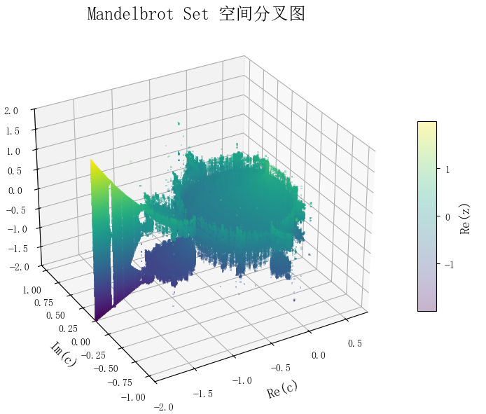

```python
fig = plt.figure(figsize=(10, 6))
ax = fig.add_subplot(111, projection='3d')

scatter = ax.scatter(vox_x, vox_y, vox_z, s=2.0, c=vox_c,
                     cmap='viridis', alpha=0.3, linewidth=0, marker='s')

ax.set_xlabel('Re(c)')
ax.set_ylabel('Im(c)')
ax.set_zlabel('Re(z)')
ax.set_title('Mandelbrot Set 空间分叉图', size=18)

ax.set_xlim(xmin, xmax)
ax.set_ylim(ymin, ymax)
ax.set_zlim(zmin, zmax)
ax.view_init(elev=30, azim=-120)

cbar = plt.colorbar(scatter, ax=ax, shrink=0.5, aspect=10)
cbar.set_label('Re(z)')
plt.tight_layout()
display_inline(fig)
```

从中我们可以看到各个周期轨道以及在实轴的混沌.

这里我们可以观察到，在周期轨道所在区域的边界处出现“毛刺”. 这里我们放大观测：

```python
w, h = 800, 600
xmin, xmax = -0.82, -0.70
ymin, ymax = 0.06, 0.16
zmin, zmax = -2.0, 2.0

max_iter = 5000
skip_iter = 2000
keep_iter = 1000
vox_res = (1000, 1000, 500)

mask = calc_mandelbrot(xmin, xmax, ymin, ymax, w, h, max_iter)
y_in_arr, x_in_arr = np.where(mask == 0)
dx_map = (xmax - xmin) / w
dy_map = (ymax - ymin) / h
c_reals = xmin + x_in_arr * dx_map
c_imags = ymin + y_in_arr * dy_map

raw_xs, raw_ys, raw_z_real = calc_bifurcation_pt(c_reals, c_imags, skip_iter, keep_iter)

bounds = (xmin, xmax, ymin, ymax, zmin, zmax)
vox_x, vox_y, vox_z, vox_c = vox_pt(raw_xs, raw_ys, raw_z_real, raw_z_real, bounds, vox_res)
```

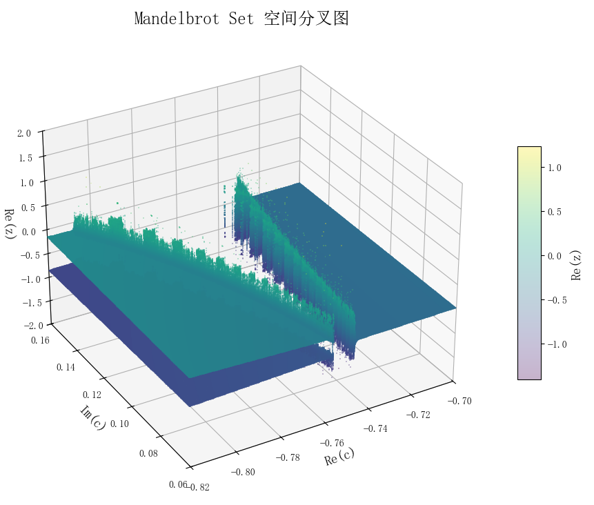

```python
fig = plt.figure(figsize=(10, 6))
ax = fig.add_subplot(111, projection='3d')

scatter = ax.scatter(vox_x, vox_y, vox_z, s=2.0, c=vox_c,
                     cmap='viridis', alpha=0.3, linewidth=0, marker='s')

ax.set_xlabel('Re(c)')
ax.set_ylabel('Im(c)')
ax.set_zlabel('Re(z)')
ax.set_title('Mandelbrot Set 空间分叉图', size=18)

ax.set_xlim(xmin, xmax)
ax.set_ylim(ymin, ymax)
ax.set_zlim(zmin, zmax)
ax.view_init(elev=30, azim=-120)

cbar = plt.colorbar(scatter, ax=ax, shrink=0.5, aspect=10)
cbar.set_label('Re(z)')
plt.tight_layout()
display_inline(fig)
```

上述分叉图对应的区域如下：

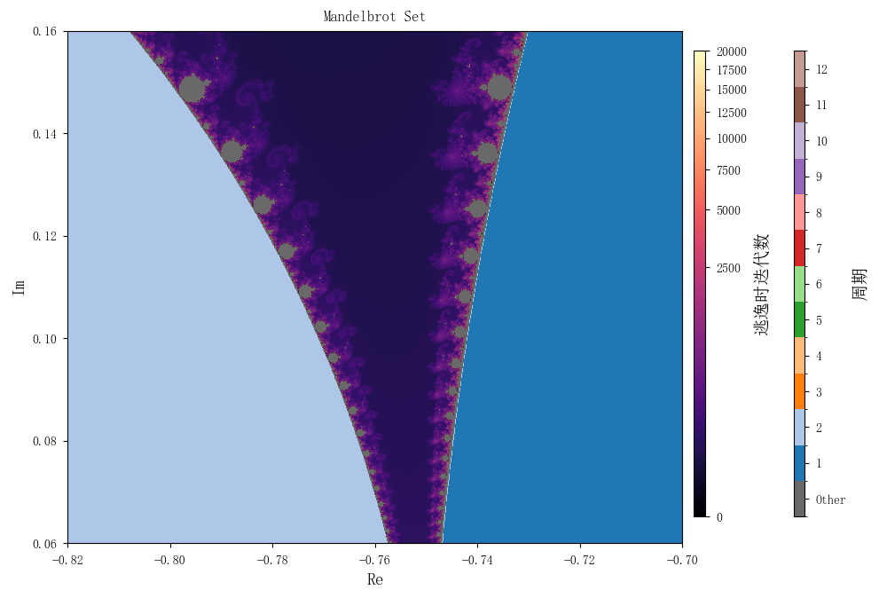

```python
width, height = 1600, 1400
xmin, xmax = -0.82, -0.70
ymin, ymax = 0.06, 0.16
max_iter = 20000
tol = 1e-5
max_period = 12

esc_map, per_map = calc_mandelbrot_with_esc_and_per(
    xmin, xmax, ymin, ymax, width, height, max_iter, tol, max_period
)

fig, ax = plt.subplots(figsize=(10, 6))

# 第一层绘制（逃逸速度）
mask_escape = np.ma.masked_equal(esc_map, max_iter)
cmap_esc = plt.cm.magma.copy()
cmap_esc.set_bad('black')
norm_esc = mpl.colors.PowerNorm(gamma=0.3, vmin=0, vmax=max_iter)
im_escape = ax.imshow(mask_escape, extent=[xmin, xmax, ymin, ymax],
                      cmap=cmap_esc, norm=norm_esc, origin='lower', interpolation='bilinear')

# 第二层绘制（周期）
mask_period = np.ma.masked_equal(per_map, 0)
base_colors = plt.cm.tab20.colors
color_list = ['dimgray'] + list(base_colors[:max_period])
cmap_period = mpl.colors.ListedColormap(color_list)
viz_period_data = per_map.copy()
viz_period_data[viz_period_data == -1] = 0

bounds = np.arange(-0.5, max_period + 1.5, 1)
norm_period = mpl.colors.BoundaryNorm(bounds, cmap_period.N)

im_period = ax.imshow(mask_period, extent=[xmin, xmax, ymin, ymax],
                      cmap=cmap_period, norm=norm_period, origin='lower', interpolation='nearest')

plt.subplots_adjust(right=0.82)

cax1 = fig.add_axes([0.76, 0.15, 0.01, 0.7])
cbar1 = plt.colorbar(im_escape, cax=cax1)
cbar1.set_label("逃逸时迭代数")

cax2 = fig.add_axes([0.85, 0.15, 0.01, 0.7])
cbar2 = plt.colorbar(im_period, cax=cax2, ticks=np.arange(0, max_period + 1))
labels = ["Other"] + [str(i) for i in range(1, max_period + 1)]
cbar2.ax.set_yticklabels(labels)
cbar2.set_label("周期")

ax.set_title("Mandelbrot Set")
ax.set_xlabel("Re")
ax.set_ylabel("Im")
display_inline(fig)
```

可见，在边界处出现“撕裂”. 同时出现自相似. 在边界处出现“混沌”.

## 结论

### Lorenz 吸引子维数

这里我们计算了 Lorenz 吸引子的维数，并和李指数维度（$2.062$）进行了对比，如下：

- 计盒维数：$D\approx 1.978, \quad E = 4\%$
- 信息维数：$D\approx 2.047, \quad E = 0.8\%$
- 关联维数：$D\approx 2.067, \quad E = 0.3\%$

对于计盒维数，其和李指数维数的相对偏差 $4\%$. 有一定理由认为其和李指数维数相同. 需要进一步给出更高精度计算或者绘制随采样点数增加的趋势观察是否收敛到 $2.062$ 确定.

对于信息维数和关联维数，其和李指数维度的相对偏差小于 $1\%$. 有较大理由认为其和李指数维数相同.

同时，对于关联维数，其使用较小的采样点就能得到较好的精度（相比信息维数，其只用了 $1/1000$ 的点就得到了更高的精度.）

### The Mandelbrot Set

这里我们绘制了 Mandelbrot Set 的外部的发散速度，内部的周期数. 并以此找到周期 1-12 对应的区域. 同时选取周期一，二，五轨道对应的 $c$ 值进行验证. 同时验证了在周期分界处同样会出现在前面 Logistic Map 出现过多的“临界慢化”现象.

另外我们绘制了 Mandelbrot Set 沿实轴的分叉图并和 Mandelbrot Set 对比. 分叉图的每一个分叉点都对应下面 Mandelbrot Set 中的每一个“大区域”的分界. 同时我们绘制了 Mandelbrot Set 的二维的分叉图，发现在边界处出现分叉图的“撕裂”，并出现混沌.

## 参考资料

- Steven. H. Strogatz, 非线性动力学与混沌 (Nonlinear Dynamics and Chaos), 2nd ed. §11.3, §11.4, §11.5
- 部分代码编写时使用 Fitten Code AI 进行补全
- 代码实现中使用 Google Gemini AI 查询了一些函数的用法.

## 致谢

感谢开源库 `nolds` 的代码实现介绍了 RANSAC 方法自动寻找线性区拟合直线.

GitHub 仓库：https://github.com/CSchoel/nolds

## 附一：问题

- Mandelbrot Set 边界的维数是什么？当然可以直接使用前面的计盒维数，信息维数，关联维数的方法计算，但受限于时间没有探索.
- 对于 Mandelbrot Set，貌似混沌只会出现在“线/网”状区域而不是某一个“连续的”区域（或者说混沌区域的面积为 $0$）. 是否正确？如何解释？

## 附二：学习心得

- 各种维数的计算方法
- Mandelbrot Set 的绘制
- RANSAC 寻找线性区域拟合